# Biomarkers: Statistical session

Alejandro Caceres

3/15/2021

# Presentation

- **Senior statistician** in the Bioinformatics group at Barcelona Institute of Global Health https://www.isglobal.org/
- Adjunct **lecturer** in statustics at the Universitat Politectica de Catalunya https://eebe.upc.edu/es
- Over 13 years of experience analyzing biomedical data
- Develop novel analysis methods for **biomarker discovery**
- High dimensional data including imaging and omic data: genomic, transcriptomic, exposomic, etc.
- I write scientific articles and implement methods in software packages (R/Matlab).

# Presentation

You can find me at:

- [linkedin](https://es.linkedin.com/in/alejandro-caceres-dominguez-7449aa176)
- [google scholar](https://scholar.google.es/citations?user=s1D-6WAAAAAJ&hl=es)
- [gitHub](https://github.com/alejandro-isglobal)
- [my blog](https://alejandro-isglobal.github.io/)

# Presentation

Analytical validation of a biomarker: Functional magnetic resonance imaging

[figure not shown]

# Presentation

Discovery of severity Biomarker: Chromosome Y function and risk of disease in men

[figure not shown]

# Aim of the talk

- What is the utility of surveying thousand/million biomarkers in drug development?
- How is biomarker utility assessed in terms of statistical evidence?

# Summary

1. Introduction:
- Biomarker definition
- Types of biomarkers (context of use)
- Guidance for qualification and reporting (FDA)
2. Statistical evidence of biomarker utility in assessing treatment efficacy:
- Biomarker’s sensitivity and specificity
- Regression analyses of biomarker levels on efficacy (stratified and with interactions by treatment)
- Multiple/Composite Biomarkers
3. Examples:
   - Assessment of HIV antiviral resistance with a composite genomic biomarker (ROC curve, pubmed: https://pubmed.ncbi.nlm.nih.gov/12060770/)
   - Prediction of Brodalumab treatment on psoriasis area severity index using gene expression data. (https://pubmed.ncbi.nlm.nih.gov/31883845/)

# Introduction: Biomarker definition

Definition:

- A biomarker is a **biological measurement** that has the potential to inform **decision-making** in relation to a clinical treatment or intervention.

Properties:

- Source material or matrix
- Method of measurement
- Purpose

# Introduction: Biomarker definition

Source material or matrix:

- specific analyte (e.g., cholesterol)
- anatomic feature (e.g., joint angle)
- physiological characteristic (e.g., blood pressure)

when they are composite

- how the compoenents are interrelated (e.g. genomic data)
- how is the process of obtaining the biomarker (e.g. algorithm, score)

# Introduction: Biomarker definition

Method of measurement:

- molecular
- histologic
- radiographic
- physiologic characteristic
- composite (algorithmic)

New biomarkers are continuously created as novel methods of measurements and their analysis is constantly developed for addressing outstanding disease-related or treatment-related **needs**.

# Introduction: Types of biomarkers

How do biomarkers inform decision-making during drug development?

Context of use (COU) is a description of the biomarker’s specific use in drug development:

1. Category:
- Disease-related: (Who should be studied?)
  - Diagnostic (selection)
  - Prognostic (stratification)
  - Susceptibility/risk (enrich)
- Treatment-related:
  - Predictive (Who should be treated?)
  - Safety (Should we stop treatment?)
  - Monitoring (Should we continue with treatment?)
  - Pharmacodynamic/response biomarker (What is the outcome of treatment? surrogate endpoint)

# Introduction: Types of biomarkers

| Role | Description |
| --- | --- |
| Diagnosis of a disease | To make a diagnosis more reliably, more rapidly, or more inexpensively than available methods |
| Severity assessment | To identify a subgroup of patients with a severe form of a disease associated with an increased probability of death or severe outcome |
| Risk assessment | To identify a subgroup of patients who may experience better (or worse) outcome when exposed to an intervention |
| Prediction of drug effects | To identify the pharmacological response of a patient exposed to a drug (efficacy, toxicity, and pharmacokinetics) |
| Monitoring | To assess the response to a therapeutic intervention |

# Introduction: Types of biomarkers

Context of use (COU) is a description of the biomarker’s specific use in drug development:

2. Use:
- Purpose of use in drug development (safety biomarker to evaluate drug-induced injury)
- Stage of use (phase 1 clinical trial)
- Population (healthy adults, psoriasis patients)
- Therapeutic mechanisms of action for which the biomarkers offer information.

# Introduction: Guidance for qualification (FDA)

Qualification of a biomarker is a determination the biomarker can be relied on to have a specific interpretation and application in drug development and regulatory review.

Biomarker Qualification: Evidentiary Framework [doc](https://alejandro-isglobal.github.io/teaching/docs/fdabiomarker.pdf)

For using a biomarker:

- what has a biomarker been qualified for?

For developing a biomarker:

- What are the evidentiary requirements for demonstrating the utility of the biomarker?

# Introduction: Guidance for qualification (FDA)

FDA Guidance for biomarker qualification (2018) for section 507 of the Federal Food, and Cosmetic Act (FD&C Act):

A. Define the **need**

- i.e disease needs and added value of the biomarker to drug development)

B. Define the context of use **COU**

- i.e Prediction: identify patients that respond to treatment

C. Assessment of **benefits** and **risks**

- i.e. Benefit: Don’t treat a patient who won´t benefit (specificity), treat a patient who will benefit (sensitivity).
- i.e. Risk: not treat a patient who could benefit, treat a patient who won´t benefit.

D. Determining evidence that is **statistically** sufficient to support COU

# Statistical evidence

D. Determining evidence that is **statistically** sufficient to support COU

1. Analytical considerations: Is the test reliable?
- validation of the Biomarkers test’s technical performance
- cost-effectiveness, feasibility
- assessment of measurement error

Gene expression biomarkers:

- RNAseq experiments have been experimentally validated, ready to include in a clinical trial
- Composite biomarkers derived from them (algorithm) need to be validated

# Statistical evidence

2. Medical considerations: Is the biomarker clinically useful biomarker?

Establish the relationship between a biomarker and an outcome of interest:

- Randomized controlled trial
- Single-arm/historical control trial
- Cohort study
- Case-control study (including nested)
- Cross-sectional study
- Case series or case reports
- Registry information
- Meta-analysis

Strongest evidence comes from **prospective studies** that are specifically designed but data from studies conducted for **other purposes** can be used to support biomarker utility.

# Statistical evidence

The aim is to provide statistical evidence for the correlation between the biomarker and the outcome according to the COU:

- Predictive biomarker: correlation between the biomarker and efficacy of treatment.

# Sensitivity and specificity

Suppose we have a collection of **treated** individuals and for each subject

- we have measured treatment efficacy as a response variable
- we have run a test to detect the presence of a biomarker

The Response measurement is dichotomous and has the events:

- yes (the patient responded to treatment)
- no (the patient did not respond to treatment)

The Biomarker measurement is dichotomous (dichotomized by a cutoff) and has the events:

- positive (the biomarker was detected)
- negative (the biomarker was not detection detected)

# Sensitivity and specificity

Each individual has two measurements: (Response, Biomarker)

| Subject | Response | Biomarker |
| --- | --- | --- |
| $s_1$ | yes | positive |
| $s_2$ | no | negative |
| $s_3$ | yes | positive |
| … | … | … |
| $s_i$ | no | positive* |
| … | … | … |
| … | … | … |
| $s_3$ | yes | negative* |
| … | … | … |

# Sensitivity and specificity

Let’s think first in terms of the response

Within those who responded to treatment (yes), how many detected with the biomarker (positive)?

-**Sensitivity** (true positive rate)

$$fr(positive|yes)=\frac{n_{positive|yes}}{n_{negative|yes}+n_{negative|yes}}$$

# Sensitivity and specificity

Let’s think first in terms of the response

Among those who did not respond to treatment (no), how many were not detected with the biomarker (negative)?

- **specificity** (True negative rate)

$$fr(negative|no)=\frac{n_{negative|no}}{n_{positive|no}+n_{negative|no}}$$

# Sensitivity and specificity

|  | Response: Yes | Response: No |
| --- | --- | --- |
| **Biomarker: positive** | $fr(positive\|yes)$ | $fr(positive\|no)$ |
| **Biomarker: negative** | $fr(negative\|yes)$ | $fr(negative\|no)$ |
| **sum** | 1 | 1 |

|  | Response: Yes | Response: No |
| --- | --- | --- |
| **Biomarker: positive** | True positive rate (**sensitivity**) | False positive rate |
| **Biomarker: negative** | False negative rate | True negative rate (**specificity**) |
| **sum** | 1 | 1 |

The trade-off between sensitivity and specificity needs to be evaluated in the Context of Use and usefulness of the biomarker’s test

# Sensitivity and specificity

Let’s think first in terms of the test

Within those whose biomarker was detected (positive), how many responded to treatment (yes)?

- **Positive predictive value**

$$fr(yes|positive)=\frac{n_{yes|positive}}{n_{yes|positive}+n_{no|positive}}$$

# Sensitivity and specificity

Let’s think first in terms of the biomarkers test

Within those whose biomarker was not detected (negative), how many did not respond to treatment (no)?

- **Negative predictive value**

$$fr(yes|negative)=\frac{n_{yes|negative}}{n_{yes|negative}+n_{no|negative}}$$

# Sensitivity and specificity

|  | Response: Yes | Response: No | sum |
| --- | --- | --- | --- |
| **Biomarker: positive** | $PPV: fr(yes\|positive)$ | $fr(no\|positive)$ | 1 |
| **Biomarker: negative** | $fr(yes\|negative)$ | $NPV: fr(no\|negative)$ | 1 |

PPV: positive predicted value NPV: negative predicted value

These are really the values that we want to know. They depend on the probability of response to treatment.

# Sensitivity and specificity

There is a way to convert from sensitivity to positive predicted value (Baye’s rule)

$$fr(yes|possitive)=\frac{fr(positive|yes)}{fr(possitive)}fr(yes)$$

which can be rewritten

$$\frac{fr(yes|possitive)}{fr(no|possitive)}=\frac{fr(positive|yes)}{1-fr(negative|no)} \frac{fr(yes)}{1-fr(yes)}$$

# Sensitivity and specificity

$$ODD_{posttest}=LHR*ODD_{pretest}$$

$LHR+=\frac{Sensitivity}{1-specificity}$

|  | LHR+ |
| --- | --- |
| Excellent Efficacy | >10 |
| Good Efficacy | 5-10 |
| Poor Efficacy | 1-5 |
| No Efficacy | 1 |

# Regression analyses

When the levels of the biomarker are continuous then a regression analysis can be used to determine the association with the outcome (response to treatment).

The type of correlation depends on the COU.

Let´s consider the following [study](https://www.nature.com/articles/s41398-019-0521-7):

**Biomarkers for response in major depression: comparing paroxetine and venlafaxine from two randomized placebo-controlled clinical studies.** Carboni et al. *Translational psychiatry*. 2019

# Regression analyses

Features of the study

Two placebo-controlled studies evaluating the efficacy and tolerability of novel drug candidates.

- Two drug treatments: paroxetine or venlafaxine as active comparators
- panel of peripheral biomarkers (including IL-6, IL-10, TNF-α, TNFRII, BDNF, CRP, MMP9 and PAI1) in depressed patients receiving paroxetine, venlafaxine, or placebo

Aim: assess the correlation between **biomarker levels** and response outcome: 17 item scale of depression symptoms; responders >50% in reduction from baseline (reduction from 2 to 1 = reduction from 10 to 5)

# Regression analyses

Demographics:

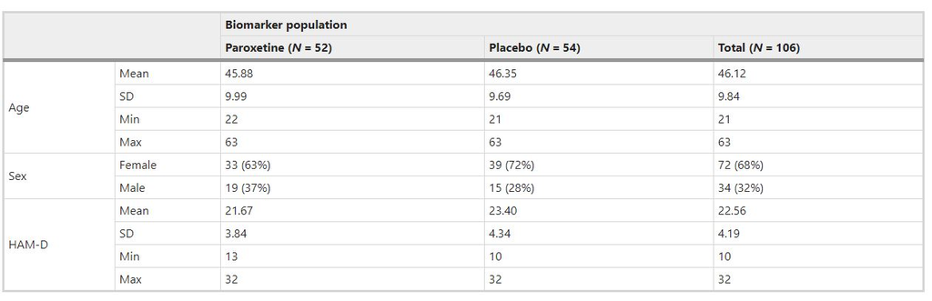

# Regression analyses

Analysis 1.

Associations between biomarker levels and depression severity at **base-line**: which are state biomarkers (CUO: diagnosis)?

$$D_{base} \rightarrow B_{base}$$

- paroxetine sutudy: IL-6 (r=0.23, p=0.018), IL-10 (r=0.19, p=0.045), stratifying by sex no significant associations were found for females.
- veroxine study: No significant correlations were found. The biomarkers do not show diagnostic capacity.

# Regression analyses

Analysis 2.

Associations between biomarkers’ changes and changes in depression symptoms: Which are biomarkers of treatment efficacy (CUO: surrogate endpoints)?

$$\Delta D=D_{w10}- D_{base} \rightarrow \Delta B= B_{w10} - B_{base}$$

Adjusting for sex and $B_{base}$ and $D_{base}$ in **full** population

# Regression analyses

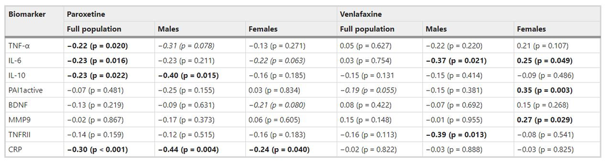

# Regression analyses

Analysis 3.

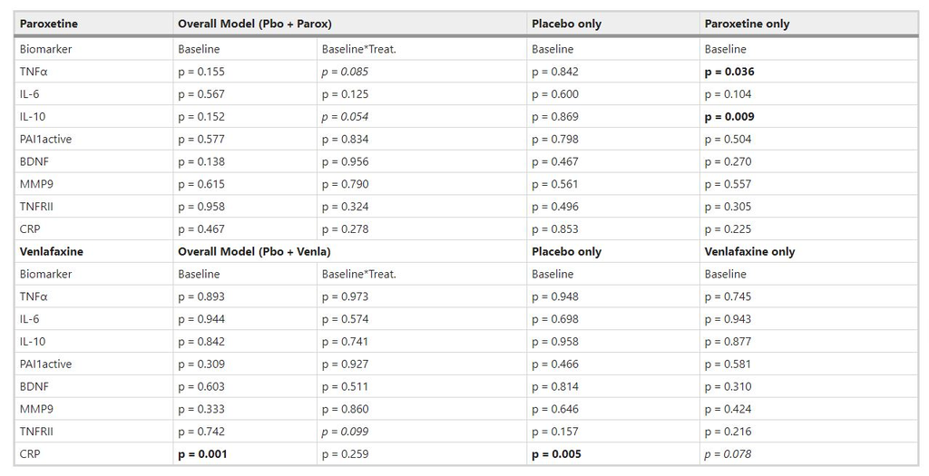

# Regression analyses

Analysis 3.

Associations between changes in symptoms and biomarkers’ levels at baseline: Which biomarkers predict improvement in symptoms when treated (CUO: prognostic under treatment biomarker)?

1. Similar to the sensibility and specificity analysis we can condition (stratify) on treated only

$$B_{base|treated} \rightarrow \Delta D$$

Adjusting by $D_{base|treated}$ and sex

- For those treated with paroxetine: IL-10 and TNF-α are at baseline were significantly associated changes in depression symptoms at week 10.

IL-10 and TNF-α showed predictive capacity under paroxetine treatment

# Regression analyses

Analysis 3.

2. Associations between changes in symptoms and biomarkers’ levels at baseline: Which biomarkers predict response when not treated (CUO: Prognosis biomarkers)?

$$B_{base|placebo} \rightarrow \Delta D$$

Adjusting by $D_{base|treated}$ and sex

- CPR was associated with improvement of symptoms in the veroxine study.

This indicates that improvement of symptoms, when treated with paroxetine, may not be due to placebo effects.

# Regression analyses

Analysis 3.

3. Associations of symptoms changes and the interaction between baseline biomarkers’ levels and treatment (CUO: Predictive biomarkers)

$$B_{base|placebo}\times T \rightarrow \Delta D$$

Adjusting by $D_{base|treated}$ and sex

- For those treated with paroxetine: treatment interactions with IL-10 and TNF-α showed a trend to significance (P=0.054, P=0.085).

While testing for interactions requires more power, this suggests that individuals with low values of IL-10 will respond better to treatment than those with high values.

Where to set the threshold?

# Multiple/Composite Biomarkers

One of the main problems when analyzing multiple biomarkers independently is **multiplicity**

- Take a biomarker with no correlation with efficacy and test the correlation in 100 clinical trials: 5% of studies with finding significant results.
- Take 100 biomarkers with no correlation with efficacy in one clinical trial: 5% of biomarkers will be declared significant.

In any such clinical trial is almost sure that will have at least one significant biomarker.

- You want that only 5% of null trials report a significant biomarker.

# Multiple/Composite Biomarkers

A correct threshold of significance (correction for multiple comparisons):

# Multiple/Composite Biomarkers

Another alternative is to **construct** a composite Biomarker.

- Computational processed and/or algorithms using machine learning and AI to discover a subset of individuals where treatment effect is maximum.
- Use the biomarkers to measure a new biological quantity that could be in the disease pathway.

# Multiple/Composite Biomarkers

Genetic mosaicisms

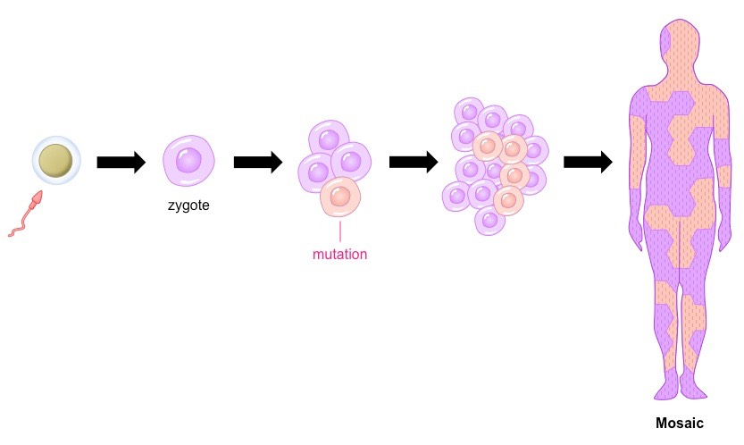

One most common somatic mutation in man is the loss of chromosome Y.

In a sample, we can measure the loss of RNA transcription from genes in chromosome Y from cells that do not produce RNA from chromosome Y because they lost it.

- We convert 1000 biomarkers into 1 with biological sense.
- We have shown that the ost of transcription of chromosome Y is associates with cancer, BMI, lower immune cell count in the blood.

# Examples

To run the examples in R.

- Install R (https://cran.r-project.org/)
- In the command line install the following packages (copy-paste the following code)

```r
if (!requireNamespace("BiocManager", quietly = TRUE))
    install.packages("BiocManager")

BiocManager::install(c("RCurl", "clusterProfiler", "cvAUC","pROC", "drc", "org.Hs.eg.db", "AnnotationDbi", "BiocGenerics", "Biobase", "sva", "limma", "repmis", ))
```

- just copy-paste in the command line all the code that I show!

# Examples

load all the libraries

```r
library(cvAUC)
library(RCurl)
library(clusterProfiler)
library(cvAUC)
library(pROC)
library(drc)
library(sva)
library(limma)
library(repmis)
```

# Examples

If we have detected one biomarker with continuous levels that is associated with efficacy, how do we select the threshold for clinical applications?

[Diversity and complexity of HIV-1 drug resistance: a bioinformatics approach to predicting phenotype from genotype](https://pubmed.ncbi.nlm.nih.gov/12060770)

- Response: Antiretroviral drug resistance
- Biomarker: Score that stratifies patients with genomic data using a machine learning method

# ROC curve

```r
hiv <- read.delim("https://alejandro-isglobal.github.io/data/hiv.txt")
head(hiv)
```

```
##   response      test
## 1        1 -0.438185
## 2        1 -0.766791
## 3        1  0.695282
## 4        1 -0.689079
## 5        1  0.325977
## 6        1  0.704040
```

# ROC curve

```r
table(hiv$response)
```

```
##
##  -1   1
## 267  78
```

- response: **no**, resistance to drug treatment: **1**
- response: **yes**, no resistance to drug treatment: **-1**

# ROC curve

```r
br <- seq(-2,2,0.25)

hist(hiv$test[hiv$response==-1],
     br=br, freq=F,xlab="RF", main="")

hist(hiv$test[hiv$response==1],
     br=br, freq=F, add=T, col="blue")

legend("toprigh",
       legend=c("yes=no resis.", "no=resis."),
       col=c(1,2), lty=1)
```

# ROC curve

[figure not shown]

cutoff at $-0.5$

- Biomarker: **positive**: $test < -0.5$
- Biomarker: **negative**: $test > -0.5$

# ROC curve

$Biomarker: positive$ when there was no resistance (yes)

Sensitivity: $fr_{[cutoff=-0.5]}(positive|yes)$

```r
mean(hiv$test[hiv$response==-1] < -0.5 )
```

```
## [1] 0.9438202
```

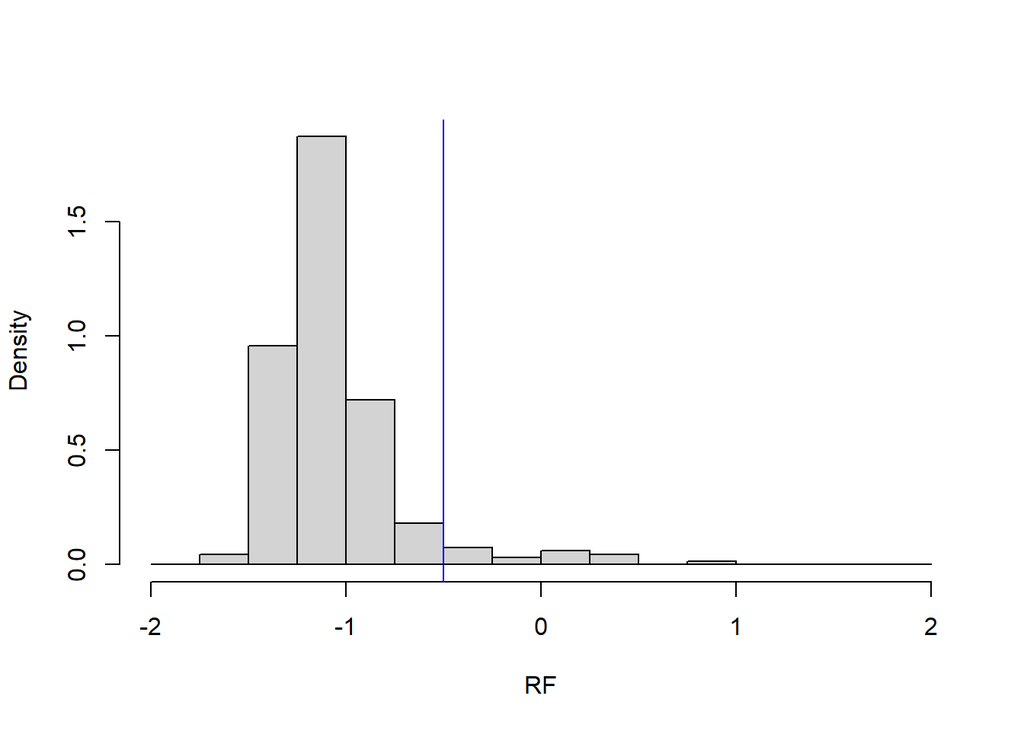

# ROC curve

$Biomarker: positive$ when there was no resistance (no)

False positive rate, $1 - specificity$: $fr_{[cutoff=-0.5]}(positive|no)$

```r
mean(hiv$test[hiv$response==1] < -0.5 )
```

```
## [1] 0.2692308
```

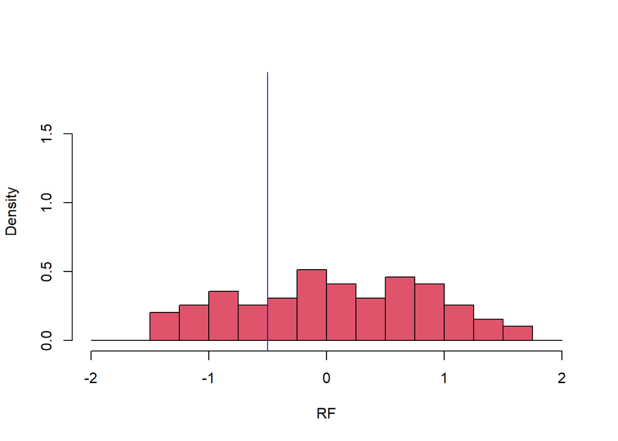

# ROC curve

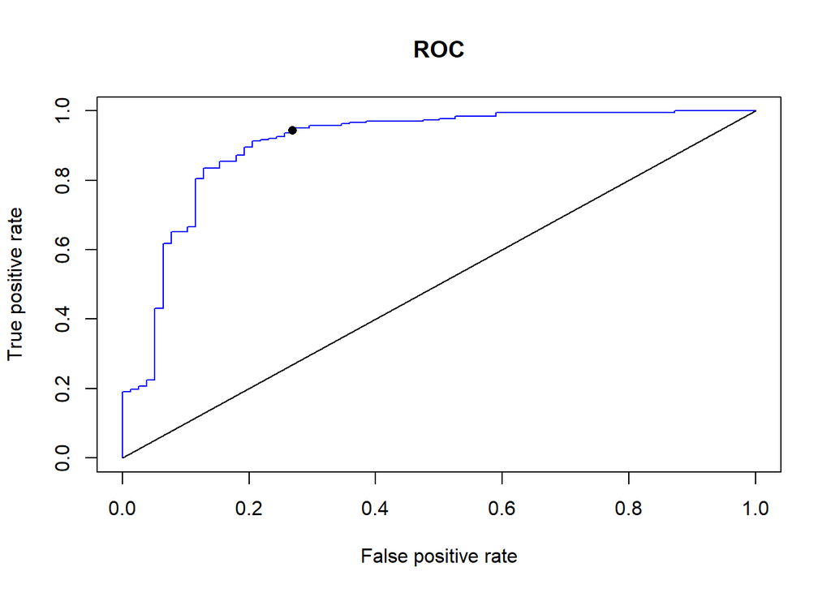

```r
out <- cvAUC(-hiv$test, -hiv$response) #compute ROC
plot(out$perf, col="blue", main="ROC") #plot
lines(c(0,1),c(0,1)); points(0.269, 0.943, pch=16) #cutoff=-0.5
```

# ROC curve

Area under the curve

$AUC=Pr(X2 < X1)$

Where $X1$ is the outcome of a positive test and $X2$ the outcome of a negative test

```r
ci.cvAUC(-hiv$test, -hiv$response)
```

```
## $cvAUC
## [1] 0.9047825
##
## $se
## [1] 0.02276935
##
## $ci
## [1] 0.8601554 0.9494096
##
## $confidence
## [1] 0.95
```

# ROC curve

```r
rocobj <- roc(-hiv$response, -hiv$test)
coords(rocobj, "best", best.method="youden")
```

```
##   threshold specificity sensitivity
## 1  0.700003   0.7948718   0.9138577
```

It optimizes $sensitivity-(1-specificity)$

# ROC curve

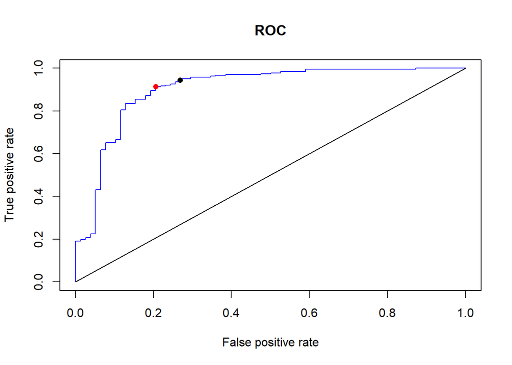

```r
out <- cvAUC(-hiv$test, -hiv$response) #calcular ROC
plot(out$perf, col="blue", main="ROC") #plot
lines(c(0,1),c(0,1)); points(0.269, 0.943, pch=16)#cutoff=-0.5
points(1-0.794, 0.9138, pch=16, col="red")  #optimal
```

# Prediction of treatment effects

[Short-term transcriptional response to IL-17 receptor-A antagonism in the treatment of psoriasis](https://pubmed.ncbi.nlm.nih.gov/31883845/%5D). JACI. 2020

[figure not shown]

# Prediction of treatment effects

- They used transcription data from a panel of genes associated with psoriasis.
- They show that the improvement in of psoriasis transcriptome with Brodalumbad treatment by responders.

COU: supprogate end point. Improvement of psoriasis transcriptome showing causal action of the drug in a biological pathway.

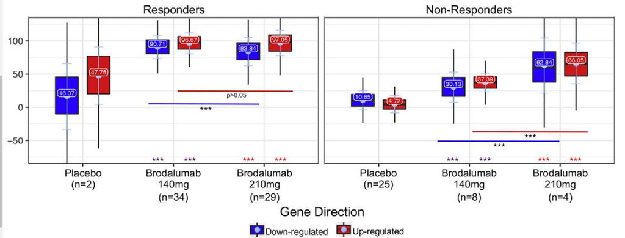

# Prediction of treatment effects

The question of whether the biomarkers can be used to predict Brodalumbad remains.

I downloaded the data from [GEO](https://www.ncbi.nlm.nih.gov/geo/query/acc.cgi?acc=GSE117468) to find predictors of the efficacy.

```r
source_data("https://github.com/alejandro-isglobal/Biomarkers/raw/master/data/GSE117468.Rdata")
```

```
## [1] "phenodat"    "expr"        "genesid"     "genesentrez"
```

# Prediction of treatment effects

```r
dim(expr)
```

```
## [1] 53951    96
```

```r
expr[1:5,1:5]
```

```
##           GSM3300910 GSM3300916 GSM3300920 GSM3300928 GSM3300932
## 1007_s_at   9.975898   8.947814  10.544516  10.088859   9.948196
## 1053_at     7.264437   7.323783   6.468845   7.648613   7.304800
## 117_at      6.066067   6.010792   6.373146   6.520405   6.567029
## 121_at      6.037013   6.100783   6.261066   5.624866   6.403674
## 1255_g_at   3.013214   2.937823   3.087177   2.914161   3.672842
```

# Prediction of treatment effects

```r
dim(phenodat)
```

```
## [1] 96  8
```

```r
head(phenodat)
```

```
##            age    bmi     patient          t   eff      effdif effbase effend
## GSM3300910  53 20.750 10216001001 brodalumab  TRUE  1.00000000    12.4    0.0
## GSM3300916  51 35.235 10216001004    placebo  TRUE  0.44791667    19.2   10.6
## GSM3300920  47 35.471 10216001005    placebo FALSE -0.16417910    13.4   15.6
## GSM3300928  38 33.272 10216003001 brodalumab  TRUE  0.85427136    19.9    2.9
## GSM3300932  47 36.553 10216003002    placebo FALSE -0.67980296    20.3   34.1
## GSM3300936  64 32.189 10216003003    placebo FALSE -0.08116883    30.8   33.3
```

- `t=1,2`: placebo, Brodalumab 210mg or 140 mg.
- `effdif`: percentage of improvement in PASI (psoriasis area-and-severity-index) between baseline and w12 (PASI (W0-W12)/W0).
- `eff=1,0`: PASI improvement W12 < W0

# Prediction of treatment effects

Analysis 1.

I aimed to test for which biomarkers significantly correlated with improvement in PASI (predictors of efficacy)

$$\Delta PASI*T \rightarrow B_{base}$$

```r
table(phenodat$eff, phenodat$t)
```

```
##
##         placebo brodalumab
##   FALSE       9          1
##   TRUE       16         70
```

only one individual under treatment did not improve PASI but 16 placebos improved PASI. Conditioning on the treated individuals is not suitable. Placebos still have information.

# Prediction of treatment effects

```r
mod0 <- model.matrix( ~  t + eff  + age + bmi, data = phenodat)
mod <- model.matrix( ~ t:eff + t + eff  + age + bmi, data = phenodat)
ns <- num.sv(expr, mod, method="be")
ss <- sva(expr, mod, mod0, n.sv=ns)$sv
modss <- cbind(mod, ss)

#estimate associations
fit <- lmFit(expr, modss)
fit <- eBayes(fit)

tt <- topTable(fit, number=Inf, coef="tbrodalumab:effTRUE")
```

# Prediction of treatment effects

```r
source_data("https://github.com/alejandro-isglobal/Biomarkers/raw/master/data/tt.RData")
```

```
## [1] "fit" "tt"
```

# Prediction of treatment effects

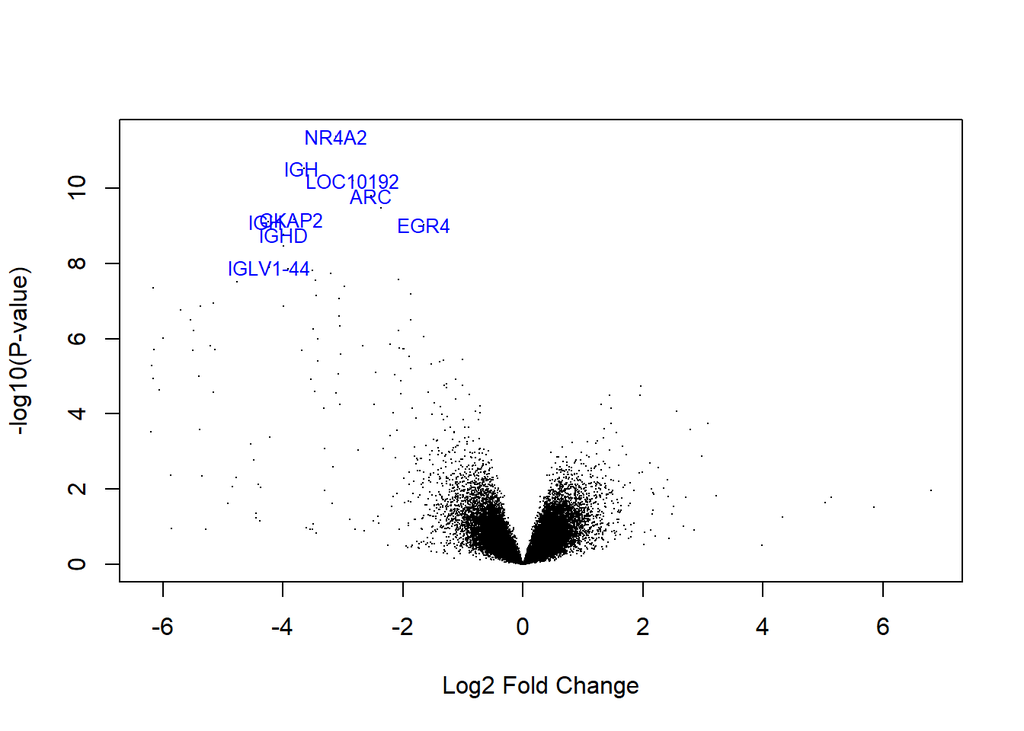

# Prediction of treatment effects

We identified 87 tranctripts from 48 genes significantly (adjsuted $P <0.05$) associated with efficacy when treated with brodalumab.

```r
trascriptname <- rownames(tt)
sigGenespso <- trascriptname[tt$adj.P.Val<0.05]
length(sigGenespso)
```

```
## [1] 87
```

# Prediction of treatment effects

We select significant genes and asked which metabolic pathways are enriched with those genes

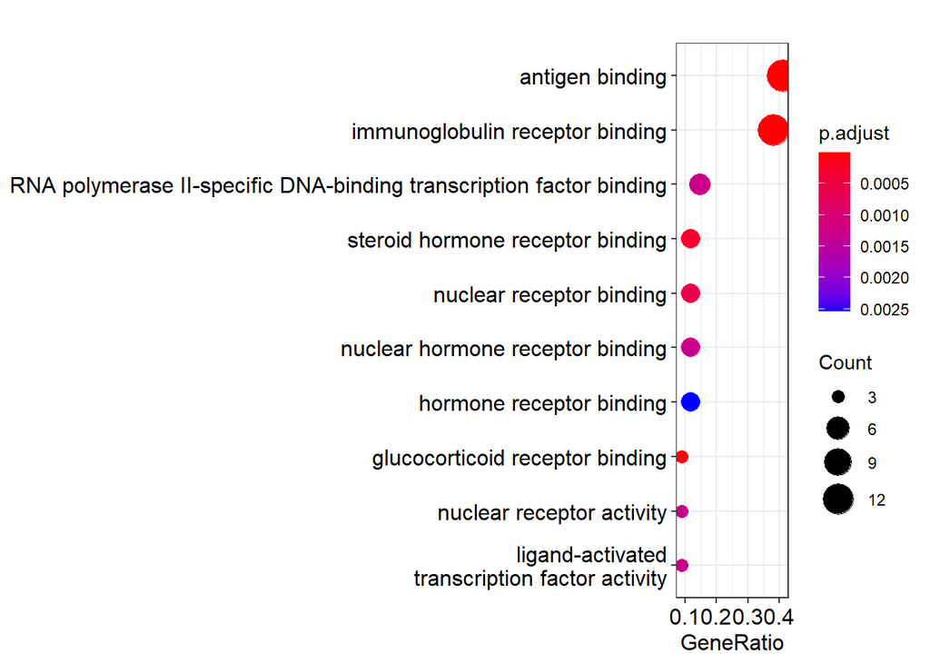

```r
#select genes in the format of ENTREZ
mappedgenesIds <- genesentrez[sigGenespso]
mappedgenesIds <- unique(unlist(strsplit(mappedgenesIds, " /// ")))


#run enrichment in GO
GO <- enrichGO(gene = mappedgenesIds, 'org.Hs.eg.db', ont="MF", pvalueCutoff=0.05, pAdjustMethod="BH")

dotplot(GO)
```

# Prediction of treatment effects

Analysis 2.

I used new causal inference methods (random causal forest) that I have recently implemented for transcriptomic data.

The method

- builds a predictor from the transcription data of the relevant genes
- estimates the probability at baseline of the response to a potential brodalumab treatment
- predict probabilities on 19 randomly selected individuals not used to build the predictor.

# Prediction of treatment effects

```r
source_data("https://github.com/alejandro-isglobal/Biomarkers/raw/master/data/pred.Rdata")
```

```
## [1] "pred"
```

# Prediction of treatment effects

- `pasi_imp` is PASI improvement: $\Delta PASI = \frac{PASI_{W0}-PASI_{W12}}{PASI_{W0}}$
- `prob` probability of brodalumab response
- `t` 1:Placebo, 2:Brodalumab

```r
head(pred)
```

```
##      pasi_imp      prob          t
## 1  0.08522727 0.3279899    placebo
## 2  1.00000000 0.3818976 brodalumab
## 3  0.92333333 0.3433848 brodalumab
## 4  0.80152672 0.3193873 brodalumab
## 5 -0.67980296 0.4011619    placebo
## 6  0.99019608 0.3488585 brodalumab
```

# Prediction of treatment effects

We can test the dose-response relationship between the brodalumab response at baseline (dose) and PASI improvement (response).

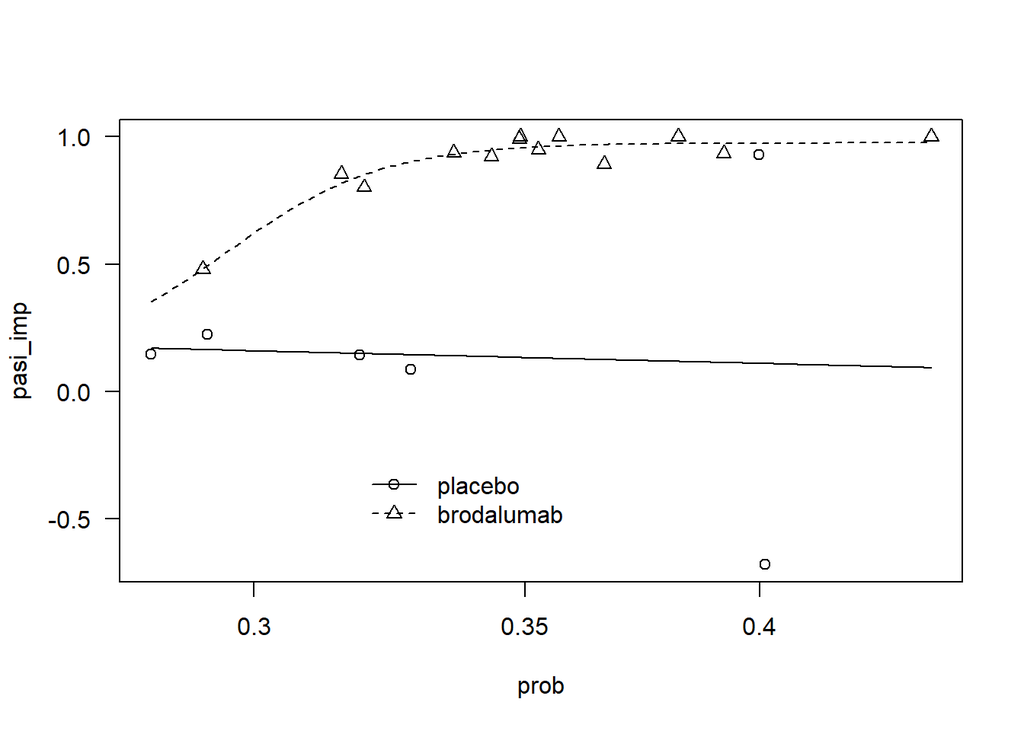

```r
met <- drm(pasi_imp ~ prob, t, fct=LL.4(), data=pred)
plot(met, legendPos=c(0.36,-0.25))
```